# Exploration of Stanford Open Policing Dataset

Linni Qin n9632981

4 March 2018

## Introduction

This Markdown document is going to present the relevant foundings while explorating the dataset of Stanford Open Policing. The dataset contains 130 million records of vehicle and pedestrian stops across 31 states of United States. The hidden relationships between police and the public provides solid foundations for the policy maker to improve the interactions between the police and the public.

With the purpose to facilate the policing policy practice in the US, this project will apply the following data manipulation skills and machine learning techniques to derive the valuable insights from datasets.

https://openpolicing.stanford.edu/data/

## In-Scope Problems (3):

1. Which age group commits the most traffic offenses? (15-99 years old drivers) TO DO: compare the driver number and their ages in the targeted states (3rd party data) TO DO: compare the census statistic in the relating states (3rd party data)
2. What type of offenses they commonly commit? - DUI, Speeding, Stop Signs, Seat Belt, or others?
3. Do those offenses happen commonly in typical state only or across the nation?

## In-Scope Datasets:

13 states provide detail values for targeted features: ——– “Driver Age” and “Violation”

# Calling or installing the useful packages

```r
library(ggplot2)
library(plyr)
library(dplyr)
library(ggmap)
```

## WARMING UP EXCERCISE - EXPLORE THE DATA OVERVIEW (31 STATES)

31 datasets relating to 31 states cover different sizes, diverse level of details and various year range. Aiming at collecting the proper datasets for initial exploration to define the direction of research, I plot the states which provides details over at least 70% of the stops.Then choose the proper size of datasets to primary epxloration.

```r
overview <- read.csv("./dataOverview.csv", header = TRUE)
ovsub <- subset(overview, select = -c(Stops, Time.Range))
#ovsub <- ovsub[,-1]

ovsubA <- data.frame(rowSums(ovsub == "x"))
names(ovsubA)[1] <- c("freq")
ovsubB <- select(ovsub, State)
ovfreq<- cbind(ovsubB,ovsubA)
ovdf <- subset(ovfreq, ovfreq$freq>8)
nrow(ovdf) #There are 12 states contains at least 70% details for more than 8 attributes
```

```
## [1] 12
```

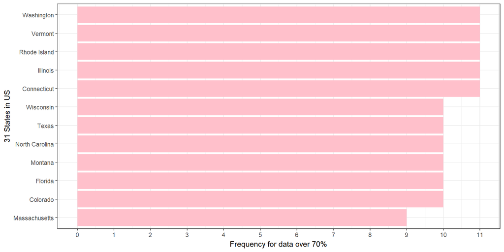

```r
ggplot(ovdf,aes(x=reorder(ovdf$State,+freq), y=freq)) + geom_bar( fill = "pink", stat = "identity") + xlab("31 States in US") + ylab("Frequency for data over 70%")+ scale_y_continuous(limits = c(0, 11), breaks = seq(0, 11, 1)) +coord_flip() + theme_bw()
```

```r
data <- merge(x=overview,y=ovdf,by="State")
data$Stops <- gsub("[,]","" ,data$Stops, perl=TRUE) #delect the character common
data$Stops <- as.numeric(data$Stops) #convert character into numeric values
summarise(data, Median=median(data$Stops), Mean= mean(data$Stops), Max=max(data$Stops), Min=min(data$Stops), Std=sd(data$Stops))
```

```
##    Median    Mean      Max    Min     Std
## 1 3001521 5059556 23397249 283285 6593427
```

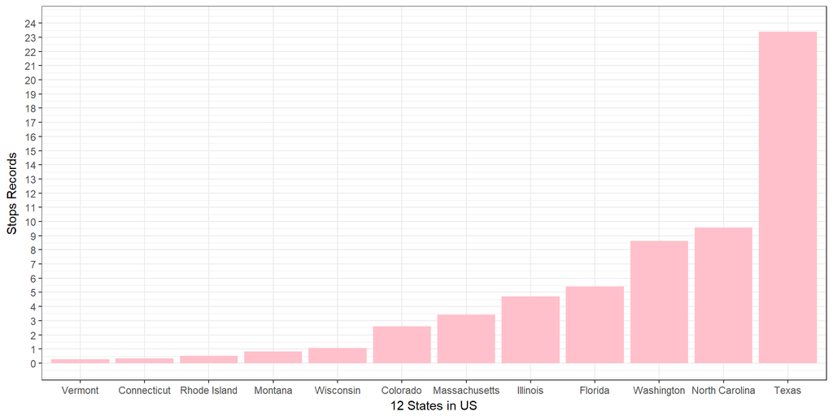

```r
ggplot(data,aes(x=reorder(data$State,+Stops), y=Stops/10^6)) + geom_bar( fill = "pink", stat = "identity") + xlab("12 States in US") + ylab("Stops Records")+ scale_y_continuous(limits = c(0, 24), breaks = seq(0, 24, 1))  + theme_bw()
```

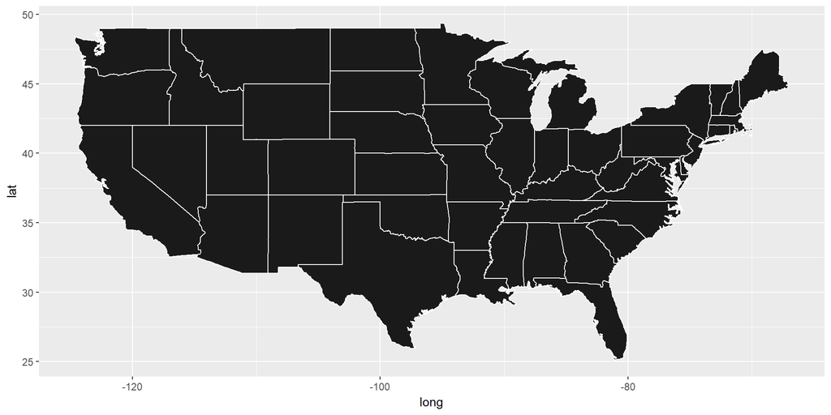

```r
#compare the states with data for 11 attributes and there stops records.
ovdf11 <- subset(ovdf, ovdf$freq == 11) #Threre are 5 states provides 11 attributes with more than 70% details

library(maps)
us <- map_data("state")

p <- ggplot()
p <- p + geom_polygon( data=us, aes(x=long, y=lat, group = group),colour="white", fill="grey10" )
p
```

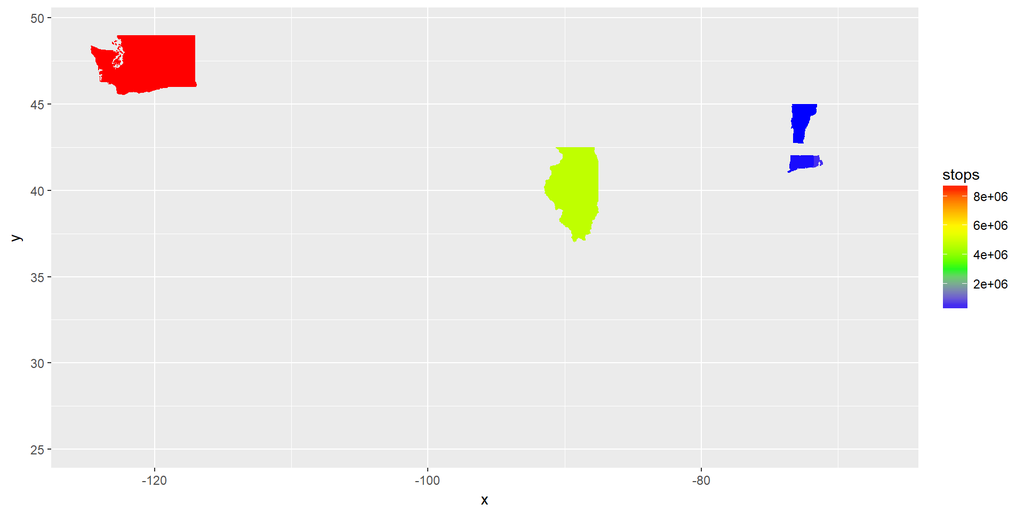

```r
data11 <- merge(x=overview,y=ovdf11,by="State")
data11$Stops <- gsub("[,]","" ,data11$Stops, perl=TRUE) #delect the character common
data11$Stops <- as.numeric(data11$Stops)

x = data.frame(region=tolower(data$State), stops=data$Stops, stringsAsFactors=F)
y = data.frame(region=tolower(data11$State), stops=data11$Stops, stringsAsFactors=F)

ggplot(y, aes(map_id = region)) + geom_map(aes(fill = stops), map = us) +
    scale_fill_gradientn(colours=c("blue","green","yellow","red")) +
    expand_limits(x = us$long, y = us$lat)
```

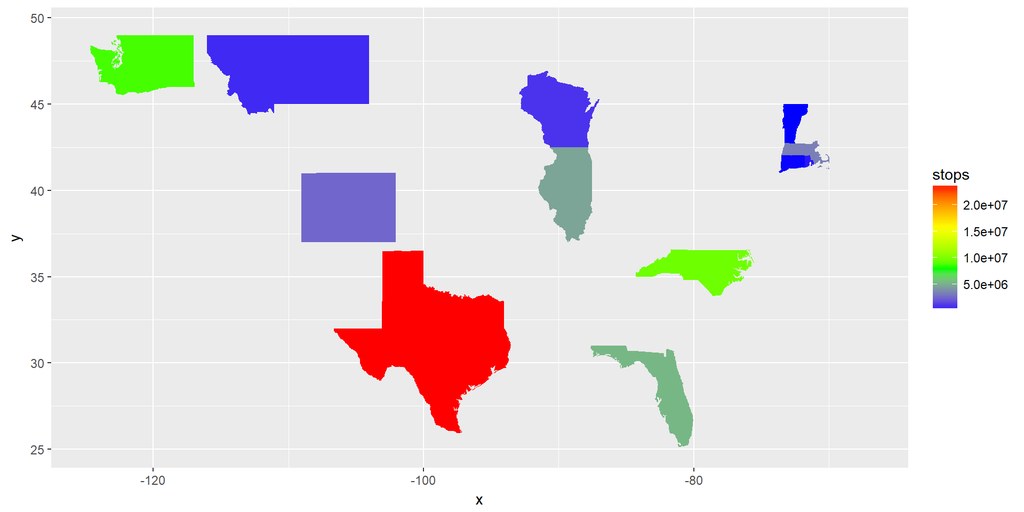

```r
ggplot(x, aes(map_id = region)) + geom_map(aes(fill = stops), map = us) +
    scale_fill_gradientn(colours=c("blue","green","yellow","red")) +
    expand_limits(x = us$long, y = us$lat)
```

Finding 1: most of states which provides better details locate in the north part of US, among then, more states are from the eastern end. Finding 2: the stops volume gets bigger when it goes to the bigger states with bigger population.

## CONNECTICUT STATE — OVERVIEW

```r
connecticut <- read.csv("./CT_cleaned.csv", header = TRUE)
sapply(connecticut, class)
```

```
##                    id                 state             stop_date
##              "factor"              "factor"              "factor"
##             stop_time          location_raw           county_name
##              "factor"              "factor"              "factor"
##           county_fips fine_grained_location     police_department
##             "integer"              "factor"              "factor"
##         driver_gender        driver_age_raw            driver_age
##              "factor"             "integer"             "numeric"
##       driver_race_raw           driver_race         violation_raw
##              "factor"              "factor"              "factor"
##             violation      search_conducted       search_type_raw
##              "factor"             "logical"              "factor"
##           search_type      contraband_found          stop_outcome
##              "factor"             "logical"              "factor"
##           is_arrested            officer_id         stop_duration
##             "logical"              "factor"              "factor"
```

```r
library(lubridate)
connecticut$stop_date <- ymd(connecticut$stop_date) #convert the class of data into right format
class(connecticut$stop_date)
```

```
## [1] "Date"
```

```r
ct2013 <- subset(connecticut, connecticut$stop_date >= "2013-01-01" & connecticut$stop_date < "2014-01-01")

ct2013$month <- months(as.Date(ct2013$stop_date, format = "%y-%m-%d"))

ct2014 <- subset(connecticut, connecticut$stop_date >= "2014-01-01" & connecticut$stop_date < "2015-01-01")

ct2014$month <- months(as.Date(ct2014$stop_date, format = "%y-%m-%d"))

ct2015 <- subset(connecticut, connecticut$stop_date >= "2015-01-01" & connecticut$stop_date < "2016-01-01")

ct2015$month <- months(as.Date(ct2015$stop_date, format = "%y-%m-%d"))
```

Check how many month invloved in each year and the sum of offenses in each subset:

```r
m13 <- ddply(ct2013, .(month), "nrow")
m14 <- ddply(ct2014, .(month), "nrow")
m15 <- ddply(ct2015, .(month), "nrow")
```

2013: Oct. Nov. Dec. 2014: Jan. – Dec. 2015: Jan. Feb. Mar.

Plot stop volume in each month:

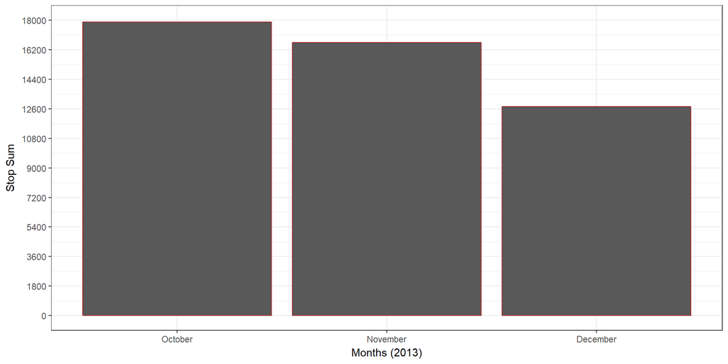

```r
m13$month <- ordered(m13$month, levels = c("January", "February", "March", "April", "May", "June", "July", "August", "September", "October","November", "December"))

ggplot(m13) + geom_bar(aes(x=month, y=nrow), stat = "identity", color = "brown") + xlab ("Months (2013)") + ylab("Stop Sum") + scale_y_continuous(limits = c(0, 18000), breaks = seq(0, 18000, 1800)) + theme_bw()
```

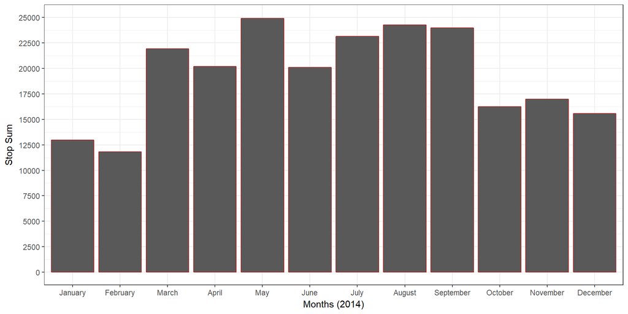

```r
m14$month <- ordered(m14$month, levels = c("January", "February", "March", "April", "May", "June", "July", "August", "September", "October","November", "December"))
ggplot(m14) + geom_bar(aes(x=month, y=nrow), stat = "identity", color = "brown") + xlab ("Months (2014)") + ylab("Stop Sum") + scale_y_continuous(limits = c(0, 25000), breaks = seq(0, 25000, 2500)) + theme_bw()
```

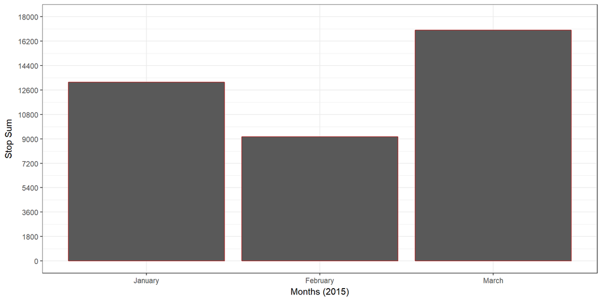

```r
m15$month <- ordered(m15$month, levels = c("January", "February", "March", "April", "May", "June", "July", "August", "September", "October","November", "December"))
ggplot(m15) + geom_bar(aes(x=month, y=nrow), stat = "identity", color = "brown") + xlab ("Months (2015)") + ylab("Stop Sum") + scale_y_continuous(limits = c(0, 18000), breaks = seq(0, 18000, 1800)) + theme_bw()
```

## DRIVER AGE 2014

## Which age group commits the most traffic offenses yearly?

# TO DO: compare the driver number and their ages in the targeted states (3rd party data)

# TO DO: compare the census statistic in the relating states (3rd party data)

Select the necessary attributes only for quick exploration.(10 fields) Referring to data standarization: https://github.com/5harad/openpolicing/blob/master/DATA-README.md

```r
class(ct2014$driver_age)
```

```
## [1] "numeric"
```

```r
ct2014 <- select(ct2014, id, stop_date,driver_gender,driver_age,driver_race, violation,search_conducted,search_type,contraband_found,month)
```

```r
# EXPLORE THE MOST POPULAR OFFENSE IN THE STATE BY ALL AGE GROUP FIRSTLY.

ctallviolation <- ddply(connecticut, .(violation), "nrow")

ctallviolation <- ctallviolation[order(-ctallviolation$nrow),]

head(ctallviolation)
```

```
##               violation   nrow
## 123            Speeding 100860
## 98                Other  87702
## 111 Registration/plates  37790
## 83     Moving violation  28150
## 1            Cell phone  20088
## 70               Lights  12105
```

```r
ct2014violation <- ddply(ct2014, .(violation), "nrow")

ct2014violation <- ct2014violation[order(-ct2014violation$nrow),]

head(ct2014violation)
```

```
##               violation  nrow
## 108            Speeding 73438
## 85                Other 63989
## 97  Registration/plates 27185
## 72     Moving violation 20139
## 1            Cell phone 14963
## 105           Seat belt 10172
```

Assign the age into individual groups: teen driver under 18, adult drivers between 18 and 65 with being seperated into multiple group every 5 years, older driver with more than 65 years old.

```r
ct2014$driver_age <- replace(ct2014$driver_age, ct2014$driver_age < 18, "15-17")
ct2014$driver_age <- replace(ct2014$driver_age, ct2014$driver_age >=18 & ct2014$driver_age < 25, "18-24")
ct2014$driver_age <- replace(ct2014$driver_age, ct2014$driver_age >=25 & ct2014$driver_age < 30, "25-29")
ct2014$driver_age <- replace(ct2014$driver_age, ct2014$driver_age >=30 & ct2014$driver_age < 35, "30-34")
ct2014$driver_age <- replace(ct2014$driver_age, ct2014$driver_age >=35 & ct2014$driver_age < 40, "35-39")
ct2014$driver_age <- replace(ct2014$driver_age, ct2014$driver_age >=40 & ct2014$driver_age < 45, "40-44")
ct2014$driver_age <- replace(ct2014$driver_age, ct2014$driver_age >=45 & ct2014$driver_age < 50, "45-49")
ct2014$driver_age <- replace(ct2014$driver_age, ct2014$driver_age >=50 & ct2014$driver_age < 55, "50-54")
ct2014$driver_age <- replace(ct2014$driver_age, ct2014$driver_age >=55 & ct2014$driver_age < 60, "55-59")
ct2014$driver_age <- replace(ct2014$driver_age, ct2014$driver_age >=60 & ct2014$driver_age < 65, "60-64")
ct2014$driver_age <- replace(ct2014$driver_age, ct2014$driver_age >= 65, "65+")
```

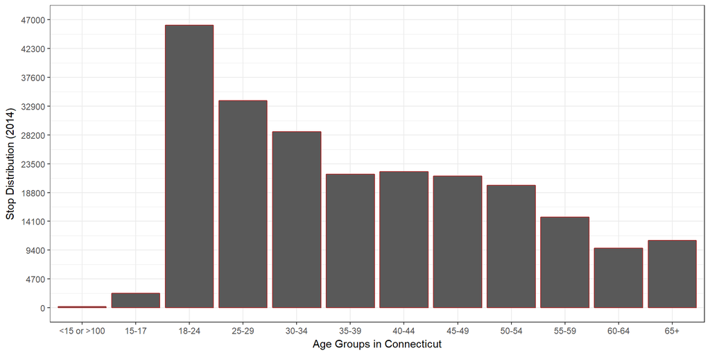

```r
age14 <- ddply(ct2014, .(driver_age), "nrow")
age14 <- replace(age14, is.na(age14), "<15 or >100")

ggplot(age14) + geom_bar(aes(x=driver_age, y=nrow), stat = "identity", color = "brown") + xlab ("Age Groups in Connecticut") + ylab("Stop Distribution (2014)") + scale_y_continuous(limits = c(0, 47000), breaks = seq(0, 47000, 4700)) + theme_bw()
```

Conclusion: (TO DO, COMPARISION)

In the state of connecticut, drivers with age between 18 and 24 commit the largest amount of offenses in 2014.Then age group 25-29 does. As to the age group of 15-17, the driver commits the offenses with least number. The reason might be there is a small number of teen driver and together with there is law restricts for the teen driver before turning adult or getting Full driver license. Groups: 35-39, 40-44, 45-49, 50-54 similar

Overall, it seems that the less offenses the driver commits the elder the driver is.

## What type of offenses they commonly commit? - DUI, Speeding, Stop Signs, Seat Belt, or others?

```r
age14_g18_24 <- subset(ct2014, ct2014$driver_age == "18-24")
age14_mviolation <- ddply(age14_g18_24, .(violation), "nrow")

age14_mviolation <- age14_mviolation[order(-age14_mviolation$nrow),]

head(age14_mviolation)
```

```
##              violation  nrow
## 63            Speeding 16094
## 49               Other 13640
## 41    Moving violation  3775
## 57 Registration/plates  3668
## 33              Lights  1968
## 61           Seat belt  1959
```

Speeding is the offense the young driver commonly commit.

```r
#Export the csv for quick exploration purpose
write.csv(age14_mviolation, file = "CT_18_24_Violation.csv", row.names = FALSE)
write.csv(ct2014, file="ct2014.csv", row.names = FALSE)
```

## MONTANA STATE — OVERVIEW

```r
montana <- read.csv("./MT_cleaned.csv", header = TRUE)
sapply(montana, class)
```

```
##                    id                 state             stop_date
##              "factor"              "factor"              "factor"
##             stop_time          location_raw           county_name
##              "factor"              "factor"              "factor"
##           county_fips fine_grained_location     police_department
##             "integer"              "factor"             "logical"
##         driver_gender        driver_age_raw            driver_age
##              "factor"             "numeric"             "numeric"
##       driver_race_raw           driver_race         violation_raw
##              "factor"              "factor"              "factor"
##             violation      search_conducted       search_type_raw
##              "factor"             "logical"              "factor"
##           search_type      contraband_found          stop_outcome
##              "factor"             "logical"              "factor"
##           is_arrested                   lat                   lon
##             "logical"             "numeric"             "numeric"
##             ethnicity                  city          out_of_state
##              "factor"              "factor"             "logical"
##          vehicle_year          vehicle_make         vehicle_model
##              "factor"              "factor"              "factor"
##         vehicle_style         search_reason      stop_outcome_raw
##              "factor"              "factor"              "factor"
```

```r
library(lubridate)
montana$stop_date <- ymd(montana$stop_date) #convert the class of data into right format
class(montana$stop_date)
```

```
## [1] "Date"
```

```r
mt2009 <- subset(montana, montana$stop_date >= "2009-01-01" & montana$stop_date < "2010-01-01")
mt2009$month <- months(as.Date(mt2009$stop_date, format = "%y-%m-%d"))

mt2010 <- subset(montana, montana$stop_date >= "2010-01-01" & montana$stop_date < "2011-01-01")
mt2010$month <- months(as.Date(mt2010$stop_date, format = "%y-%m-%d"))

mt2011 <- subset(montana, montana$stop_date >= "2011-01-01" & montana$stop_date < "2012-01-01")
mt2011$month <- months(as.Date(mt2011$stop_date, format = "%y-%m-%d"))

mt2012 <- subset(montana, montana$stop_date >= "2012-01-01" & montana$stop_date < "2013-01-01")
mt2012$month <- months(as.Date(mt2012$stop_date, format = "%y-%m-%d"))

mt2013 <- subset(montana, montana$stop_date >= "2013-01-01" & montana$stop_date < "2014-01-01")
mt2013$month <- months(as.Date(mt2013$stop_date, format = "%y-%m-%d"))

mt2014 <- subset(montana, montana$stop_date >= "2014-01-01" & montana$stop_date < "2015-01-01")
mt2014$month <- months(as.Date(mt2014$stop_date, format = "%y-%m-%d"))

mt2015 <- subset(montana, montana$stop_date >= "2015-01-01" & montana$stop_date < "2016-01-01")
mt2015$month <- months(as.Date(mt2015$stop_date, format = "%y-%m-%d"))

mt2016 <- subset(montana, montana$stop_date >= "2016-01-01" & montana$stop_date < "2017-01-01")
mt2016$month <- months(as.Date(mt2016$stop_date, format = "%y-%m-%d"))
```

Check how many month invloved in each year and the sum of offenses in each subset:

```r
mt_m09 <- ddply(mt2009, .(month), "nrow")
mt_m10 <- ddply(mt2010, .(month), "nrow")
mt_m11 <- ddply(mt2011, .(month), "nrow")
mt_m12 <- ddply(mt2012, .(month), "nrow")
mt_m13 <- ddply(mt2013, .(month), "nrow")
mt_m14 <- ddply(mt2014, .(month), "nrow")
mt_m15 <- ddply(mt2015, .(month), "nrow")
mt_m16 <- ddply(mt2016, .(month), "nrow")
```

There are 12 month’s data for each year in the stat of Montana.

# TO DO: compare the driver number and their ages in the targeted states (3rd party data)

# TO DO: compare the census statistic in the relating states (3rd party data)

```r
class(mt2014$driver_age)
```

```
## [1] "numeric"
```

```r
mt2009 <- select(mt2009, stop_date,driver_age, violation)
mt2011 <- select(mt2011, stop_date,driver_age, violation)
mt2012 <- select(mt2012, stop_date,driver_age, violation)
mt2013 <- select(mt2013, stop_date,driver_age, violation)
mt2014 <- select(mt2014, stop_date,driver_age, violation)
mt2015 <- select(mt2015, stop_date,driver_age, violation)
mt2016 <- select(mt2016, stop_date,driver_age, violation)
```

Assign the age into individual groups: teen driver under 18, adult drivers between 18 and 65 with being seperated into multiple group every 5 years, older driver with more than 65 years old.

## EXPLORE MONTANA 2012

```r
mt2012$driver_age <- replace(mt2012$driver_age, mt2012$driver_age < 18, "15-17")
mt2012$driver_age <- replace(mt2012$driver_age, mt2012$driver_age >=18 & mt2012$driver_age < 25, "18-24")
mt2012$driver_age <- replace(mt2012$driver_age, mt2012$driver_age >=25 & mt2012$driver_age < 30, "25-29")
mt2012$driver_age <- replace(mt2012$driver_age, mt2012$driver_age >=30 & mt2012$driver_age < 35, "30-34")
mt2012$driver_age <- replace(mt2012$driver_age, mt2012$driver_age >=35 & mt2012$driver_age < 40, "35-39")
mt2012$driver_age <- replace(mt2012$driver_age, mt2012$driver_age >=40 & mt2012$driver_age < 45, "40-44")
mt2012$driver_age <- replace(mt2012$driver_age, mt2012$driver_age >=45 & mt2012$driver_age < 50, "45-49")
mt2012$driver_age <- replace(mt2012$driver_age, mt2012$driver_age >=50 & mt2012$driver_age < 55, "50-54")
mt2012$driver_age <- replace(mt2012$driver_age, mt2012$driver_age >=55 & mt2012$driver_age < 60, "55-59")
mt2012$driver_age <- replace(mt2012$driver_age, mt2012$driver_age >=60 & mt2012$driver_age < 65, "60-64")
mt2012$driver_age <- replace(mt2012$driver_age, mt2012$driver_age >= 65, "65+")
```

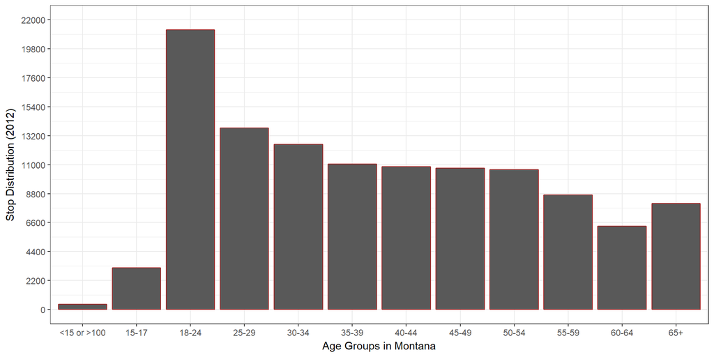

```r
mt_age12 <- ddply(mt2012, .(driver_age), "nrow")
mt_age12 <- replace(mt_age12, is.na(mt_age12), "<15 or >100")

ggplot(mt_age12) + geom_bar(aes(x=driver_age, y=nrow), stat = "identity", color = "brown") + xlab ("Age Groups in Montana") + ylab("Stop Distribution (2012)") + scale_y_continuous(limits = c(0, 22000), breaks = seq(0, 22000, 2200)) + theme_bw()
```

## What type of offenses they commonly commit? - DUI, Speeding, Stop Signs, Seat Belt, or others?

```r
# EXPLORE THE MOST POPULAR OFFENSE IN THE STATE BY ALL AGE GROUP FIRSTLY.

mtallviolation <- ddply(montana, .(violation), "nrow")

mtallviolation <- mtallviolation[order(-mtallviolation$nrow),]

head(mtallviolation)
```

```
##                      violation   nrow
## 327                   Speeding 336980
## 180           License,Speeding  58572
## 291         Paperwork,Speeding  46513
## 186                     Lights  42809
## 162 License,Paperwork,Speeding  28708
## 309              Safe movement  26136
```

```r
mt2014violation <- ddply(mt2014, .(violation), "nrow")

mt2014violation <- mt2014violation[order(-mt2014violation$nrow),]

head(mt2014violation)
```

```
##                      violation  nrow
## 264                   Speeding 41308
## 146           License,Speeding  7924
## 232         Paperwork,Speeding  6921
## 151                     Lights  5673
## 130 License,Paperwork,Speeding  4310
## 248              Safe movement  3554
```

```r
mt_age12_g18_24 <- subset(mt2012, mt2012$driver_age == "18-24")
mt_age12_mviolation <- ddply(mt_age12_g18_24, .(violation), "nrow")

mt_age12_mviolation <- mt_age12_mviolation[order(-mt_age12_mviolation$nrow),]

head(mt_age12_mviolation)
```

```
##                      violation nrow
## 190                   Speeding 8511
## 106           License,Speeding 1618
## 165         Paperwork,Speeding 1275
## 110                     Lights 1106
## 91  License,Paperwork,Speeding  805
## 169        Registration/plates  529
```

## EXPLORE MONTANA 2013

```r
mt2013$driver_age <- replace(mt2013$driver_age, mt2013$driver_age < 18, "15-17")
mt2013$driver_age <- replace(mt2013$driver_age, mt2013$driver_age >=18 & mt2013$driver_age < 25, "18-24")
mt2013$driver_age <- replace(mt2013$driver_age, mt2013$driver_age >=25 & mt2013$driver_age < 30, "25-29")
mt2013$driver_age <- replace(mt2013$driver_age, mt2013$driver_age >=30 & mt2013$driver_age < 35, "30-34")
mt2013$driver_age <- replace(mt2013$driver_age, mt2013$driver_age >=35 & mt2013$driver_age < 40, "35-39")
mt2013$driver_age <- replace(mt2013$driver_age, mt2013$driver_age >=40 & mt2013$driver_age < 45, "40-44")
mt2013$driver_age <- replace(mt2013$driver_age, mt2013$driver_age >=45 & mt2013$driver_age < 50, "45-49")
mt2013$driver_age <- replace(mt2013$driver_age, mt2013$driver_age >=50 & mt2013$driver_age < 55, "50-54")
mt2013$driver_age <- replace(mt2013$driver_age, mt2013$driver_age >=55 & mt2013$driver_age < 60, "55-59")
mt2013$driver_age <- replace(mt2013$driver_age, mt2013$driver_age >=60 & mt2013$driver_age < 65, "60-64")
mt2013$driver_age <- replace(mt2013$driver_age, mt2013$driver_age >= 65, "65+")
```

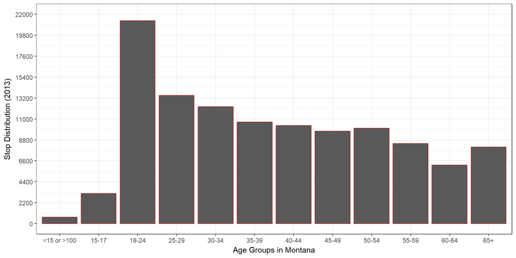

```r
mt_age13 <- ddply(mt2013, .(driver_age), "nrow")
mt_age13 <- replace(mt_age13, is.na(mt_age13), "<15 or >100")

ggplot(mt_age13) + geom_bar(aes(x=driver_age, y=nrow), stat = "identity", color = "brown") + xlab ("Age Groups in Montana") + ylab("Stop Distribution (2013)") + scale_y_continuous(limits = c(0, 22000), breaks = seq(0, 22000, 2200)) + theme_bw()
```

## What type of offenses they commonly commit? - DUI, Speeding, Stop Signs, Seat Belt, or others?

```r
mt_age13_g18_24 <- subset(mt2013, mt2013$driver_age == "18-24")
mt_age13_mviolation <- ddply(mt_age13_g18_24, .(violation), "nrow")

mt_age13_mviolation <- mt_age13_mviolation[order(-mt_age13_mviolation$nrow),]

head(mt_age13_mviolation)
```

```
##                      violation nrow
## 209                   Speeding 7780
## 115           License,Speeding 1603
## 184         Paperwork,Speeding 1200
## 120                     Lights 1110
## 101 License,Paperwork,Speeding  823
## 197              Safe movement  572
```

Speeding is the offense the young driver commonly commit.(SAME)

## EXPLORE MONTANA 2014

```r
mt2014$driver_age <- replace(mt2014$driver_age, mt2014$driver_age < 18, "15-17")
mt2014$driver_age <- replace(mt2014$driver_age, mt2014$driver_age >=18 & mt2014$driver_age < 25, "18-24")
mt2014$driver_age <- replace(mt2014$driver_age, mt2014$driver_age >=25 & mt2014$driver_age < 30, "25-29")
mt2014$driver_age <- replace(mt2014$driver_age, mt2014$driver_age >=30 & mt2014$driver_age < 35, "30-34")
mt2014$driver_age <- replace(mt2014$driver_age, mt2014$driver_age >=35 & mt2014$driver_age < 40, "35-39")
mt2014$driver_age <- replace(mt2014$driver_age, mt2014$driver_age >=40 & mt2014$driver_age < 45, "40-44")
mt2014$driver_age <- replace(mt2014$driver_age, mt2014$driver_age >=45 & mt2014$driver_age < 50, "45-49")
mt2014$driver_age <- replace(mt2014$driver_age, mt2014$driver_age >=50 & mt2014$driver_age < 55, "50-54")
mt2014$driver_age <- replace(mt2014$driver_age, mt2014$driver_age >=55 & mt2014$driver_age < 60, "55-59")
mt2014$driver_age <- replace(mt2014$driver_age, mt2014$driver_age >=60 & mt2014$driver_age < 65, "60-64")
mt2014$driver_age <- replace(mt2014$driver_age, mt2014$driver_age >= 65, "65+")
```

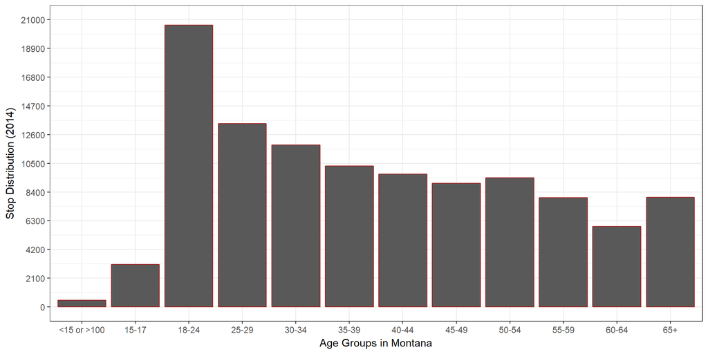

```r
mt_age14 <- ddply(mt2014, .(driver_age), "nrow")
mt_age14 <- replace(mt_age14, is.na(mt_age14), "<15 or >100")

ggplot(mt_age14) + geom_bar(aes(x=driver_age, y=nrow), stat = "identity", color = "brown") + xlab ("Age Groups in Montana") + ylab("Stop Distribution (2014)") + scale_y_continuous(limits = c(0, 21000), breaks = seq(0, 21000, 2100)) + theme_bw()
```

Conclusion: (TO DO, COMPARISION)

In the state of Montana, similar with state of Connecticut, drivers in age group 18-24 commit the most amount of offenses.

## What type of offenses they commonly commit? - DUI, Speeding, Stop Signs, Seat Belt, or others?

```r
mt_age14_g18_24 <- subset(mt2014, mt2014$driver_age == "18-24")
mt_age14_mviolation <- ddply(mt_age14_g18_24, .(violation), "nrow")

mt_age14_mviolation <- mt_age14_mviolation[order(-mt_age14_mviolation$nrow),]

head(mt_age14_mviolation)
```

```
##                      violation nrow
## 209                   Speeding 6448
## 117           License,Speeding 1542
## 186         Paperwork,Speeding 1429
## 104 License,Paperwork,Speeding  963
## 122                     Lights  963
## 197              Safe movement  482
```

Speeding is the offense the young driver commonly commit.(SAME)

## Rhode Island STATE — OVERVIEW

```r
ri <- read.csv("./RI_cleaned.csv", header = TRUE)
sapply(ri, class)
```

```
##                    id                 state             stop_date
##              "factor"              "factor"              "factor"
##             stop_time          location_raw           county_name
##              "factor"              "factor"             "logical"
##           county_fips fine_grained_location     police_department
##             "logical"             "logical"              "factor"
##         driver_gender        driver_age_raw            driver_age
##              "factor"             "numeric"             "numeric"
##       driver_race_raw           driver_race         violation_raw
##              "factor"              "factor"              "factor"
##             violation      search_conducted       search_type_raw
##              "factor"             "logical"              "factor"
##           search_type      contraband_found          stop_outcome
##              "factor"             "logical"              "factor"
##           is_arrested         stop_duration          out_of_state
##             "logical"              "factor"             "logical"
##    drugs_related_stop              district
##             "logical"              "factor"
```

```r
ri$stop_date <- ymd(ri$stop_date) #convert the class of data into right format
class(ri$stop_date)
```

```
## [1] "Date"
```

Rhode Island dataset consists of the value ranging from 2005 to 2015.

```r
ri2013 <- subset(ri, ri$stop_date >= "2013-01-01" & ri$stop_date < "2014-01-01")
ri2013$month <- months(as.Date(ri2013$stop_date, format = "%y-%m-%d"))

ri2014 <- subset(ri, ri$stop_date >= "2014-01-01" & ri$stop_date < "2015-01-01")
ri2014$month <- months(as.Date(ri2014$stop_date, format = "%y-%m-%d"))

ri2015 <- subset(ri, ri$stop_date >= "2015-01-01" & ri$stop_date < "2016-01-01")
ri2015$month <- months(as.Date(ri2015$stop_date, format = "%y-%m-%d"))
```

Check how many month invloved in each year and the sum of offenses in each subset:

```r
ri_m13 <- ddply(ri2013, .(month), "nrow")
ri_m14 <- ddply(ri2014, .(month), "nrow")
ri_m15 <- ddply(ri2015, .(month), "nrow")
```

## DRIVER AGE – Rhode Island

# TO DO: compare the driver number and their ages in the targeted states (3rd party data)

# TO DO: compare the census statistic in the relating states (3rd party data)

```r
ri2013 <- select(ri2013, stop_date,driver_age, violation)
ri2014 <- select(ri2014, stop_date,driver_age, violation)
ri2015 <- select(ri2015, stop_date,driver_age, violation)
```

## EXPLORE Rhode Island 2014

```r
ri2014$driver_age <- replace(ri2014$driver_age, ri2014$driver_age < 18, "15-17")
ri2014$driver_age <- replace(ri2014$driver_age, ri2014$driver_age >=18 & ri2014$driver_age < 25, "18-24")
ri2014$driver_age <- replace(ri2014$driver_age, ri2014$driver_age >=25 & ri2014$driver_age < 30, "25-29")
ri2014$driver_age <- replace(ri2014$driver_age, ri2014$driver_age >=30 & ri2014$driver_age < 35, "30-34")
ri2014$driver_age <- replace(ri2014$driver_age, ri2014$driver_age >=35 & ri2014$driver_age < 40, "35-39")
ri2014$driver_age <- replace(ri2014$driver_age, ri2014$driver_age >=40 & ri2014$driver_age < 45, "40-44")
ri2014$driver_age <- replace(ri2014$driver_age, ri2014$driver_age >=45 & ri2014$driver_age < 50, "45-49")
ri2014$driver_age <- replace(ri2014$driver_age, ri2014$driver_age >=50 & ri2014$driver_age < 55, "50-54")
ri2014$driver_age <- replace(ri2014$driver_age, ri2014$driver_age >=55 & ri2014$driver_age < 60, "55-59")
ri2014$driver_age <- replace(ri2014$driver_age, ri2014$driver_age >=60 & ri2014$driver_age < 65, "60-64")
ri2014$driver_age <- replace(ri2014$driver_age, ri2014$driver_age >= 65, "65+")
```

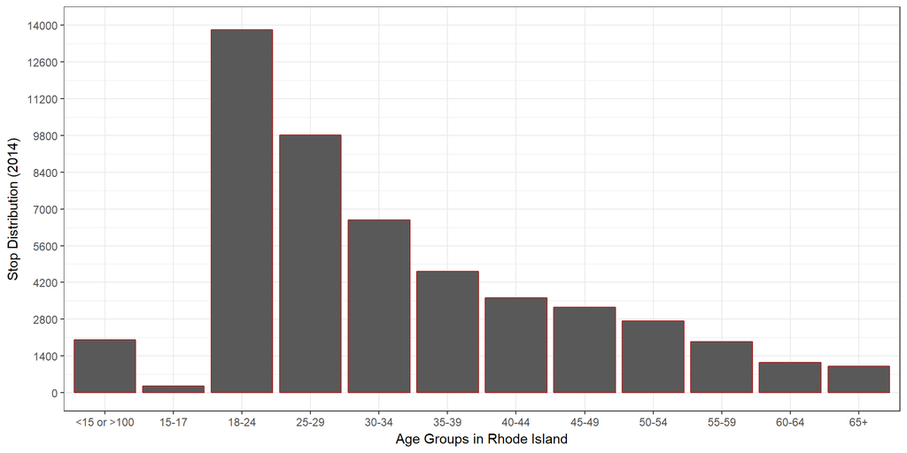

```r
ri_age14 <- ddply(ri2014, .(driver_age), "nrow")
ri_age14  <- replace(ri_age14, is.na(ri_age14), "<15 or >100")

ggplot(ri_age14) + geom_bar(aes(x=driver_age, y=nrow), stat = "identity", color = "brown") + xlab ("Age Groups in Rhode Island") + ylab("Stop Distribution (2014)") + scale_y_continuous(limits = c(0, 14000), breaks = seq(0, 14000, 1400)) + theme_bw()
```

## What type of offenses they commonly commit? - DUI, Speeding, Stop Signs, Seat Belt, or others?

```r
# EXPLORE THE MOST POPULAR OFFENSE IN THE STATE BY ALL AGE GROUP FIRSTLY.

riallviolation <- ddply(ri, .(violation), "nrow")

riallviolation <- riallviolation[order(-riallviolation$nrow),]

head(riallviolation)
```

```
##             violation   nrow
## 7            Speeding 268744
## 3    Moving violation  90234
## 2           Equipment  61252
## 1                      29073
## 4               Other  24221
## 5 Registration/plates  19830
```

```r
ri2014violation <- ddply(ri2014, .(violation), "nrow")

ri2014violation <- ri2014violation[order(-ri2014violation$nrow),]

head(ri2014violation)
```

```
##             violation  nrow
## 7            Speeding 21946
## 2           Equipment  8672
## 3    Moving violation  8165
## 6           Seat belt  6864
## 5 Registration/plates  2092
## 1                      1930
```

```r
ri_age14_g18_24 <- subset(ri2014, ri2014$driver_age == "18-24")
ri_age14_mviolation <- ddply(ri_age14_g18_24, .(violation), "nrow")

ri_age14_mviolation <- ri_age14_mviolation[order(-ri_age14_mviolation$nrow),]

head(ri_age14_mviolation)
```

```
##             violation nrow
## 6            Speeding 6147
## 1           Equipment 2701
## 2    Moving violation 2127
## 5           Seat belt 2048
## 4 Registration/plates  508
## 3               Other  287
```

## VERMONT STATE — OVERVIEW

```r
vt <- read.csv("./VT_cleaned.csv", header = TRUE)
sapply(vt, class)
```

```
##                    id                 state             stop_date
##              "factor"              "factor"              "factor"
##             stop_time          location_raw           county_name
##              "factor"              "factor"              "factor"
##           county_fips fine_grained_location     police_department
##             "integer"              "factor"              "factor"
##         driver_gender        driver_age_raw            driver_age
##              "factor"             "integer"             "numeric"
##       driver_race_raw           driver_race         violation_raw
##              "factor"              "factor"              "factor"
##             violation      search_conducted       search_type_raw
##              "factor"             "logical"              "factor"
##           search_type      contraband_found          stop_outcome
##              "factor"             "logical"              "factor"
##           is_arrested            officer_id
##             "logical"             "integer"
```

```r
vt$stop_date <- ymd(vt$stop_date) #convert the class of data into right format
class(vt$stop_date)
```

```
## [1] "Date"
```

Vermont dataset consists of the value ranging from 2010 to 2015.

```r
vt2014 <- subset(vt, vt$stop_date >= "2014-01-01" & vt$stop_date < "2015-01-01")
vt2014$month <- months(as.Date(vt2014$stop_date, format = "%y-%m-%d"))
```

Check how many month invloved in each year and the sum of offenses in each subset:

```r
vt_m14 <- ddply(vt2014, .(month), "nrow")
```

# TO DO: compare the driver number and their ages in the targeted states (3rd party data)

# TO DO: compare the census statistic in the relating states (3rd party data)

```r
vt2014 <- select(vt2014, stop_date,driver_age, violation)
```

## EXPLORE Vermont 2014

```r
vt2014$driver_age <- replace(vt2014$driver_age, vt2014$driver_age < 18, "15-17")
vt2014$driver_age <- replace(vt2014$driver_age, vt2014$driver_age >=18 & vt2014$driver_age < 25, "18-24")
vt2014$driver_age <- replace(vt2014$driver_age, vt2014$driver_age >=25 & vt2014$driver_age < 30, "25-29")
vt2014$driver_age <- replace(vt2014$driver_age, vt2014$driver_age >=30 & vt2014$driver_age < 35, "30-34")
vt2014$driver_age <- replace(vt2014$driver_age, vt2014$driver_age >=35 & vt2014$driver_age < 40, "35-39")
vt2014$driver_age <- replace(vt2014$driver_age, vt2014$driver_age >=40 & vt2014$driver_age < 45, "40-44")
vt2014$driver_age <- replace(vt2014$driver_age, vt2014$driver_age >=45 & vt2014$driver_age < 50, "45-49")
vt2014$driver_age <- replace(vt2014$driver_age, vt2014$driver_age >=50 & vt2014$driver_age < 55, "50-54")
vt2014$driver_age <- replace(vt2014$driver_age, vt2014$driver_age >=55 & vt2014$driver_age < 60, "55-59")
vt2014$driver_age <- replace(vt2014$driver_age, vt2014$driver_age >=60 & vt2014$driver_age < 65, "60-64")
vt2014$driver_age <- replace(vt2014$driver_age, vt2014$driver_age >= 65, "65+")
```

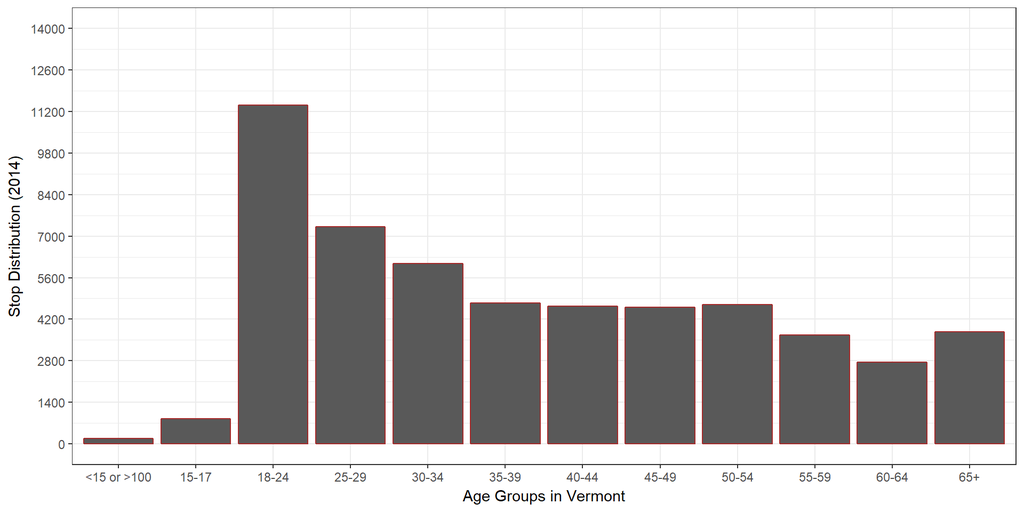

```r
vt_age14 <- ddply(vt2014, .(driver_age), "nrow")
vt_age14  <- replace(vt_age14, is.na(vt_age14), "<15 or >100")

ggplot(vt_age14) + geom_bar(aes(x=driver_age, y=nrow), stat = "identity", color = "brown") + xlab ("Age Groups in Vermont") + ylab("Stop Distribution (2014)") + scale_y_continuous(limits = c(0, 14000), breaks = seq(0, 14000, 1400)) + theme_bw()
```

## What type of offenses they commonly commit? - DUI, Speeding, Stop Signs, Seat Belt, or others?

```r
# EXPLORE THE MOST POPULAR OFFENSE IN THE STATE BY ALL AGE GROUP FIRSTLY.

vtallviolation <- ddply(vt, .(violation), "nrow")

vtallviolation <- vtallviolation[order(-vtallviolation$nrow),]

head(vtallviolation)
```

```
##            violation   nrow
## 4   Moving violation 218302
## 3          Equipment  51934
## 5              Other  10120
## 1                      2178
## 2                DUI    749
## 6 Other (non-mapped)      2
```

```r
vt2014violation <- ddply(vt2014, .(violation), "nrow")

vt2014violation <- vt2014violation[order(-vt2014violation$nrow),]

head(vt2014violation)
```

```
##          violation  nrow
## 4 Moving violation 40743
## 3        Equipment 11182
## 5            Other  2141
## 1                    521
## 2              DUI   102
```

```r
vt_age14_g18_24 <- subset(vt2014, vt2014$driver_age == "18-24")
vt_age14_mviolation <- ddply(vt_age14_g18_24, .(violation), "nrow")

vt_age14_mviolation <- vt_age14_mviolation[order(-vt_age14_mviolation$nrow),]

head(vt_age14_mviolation)
```

```
##          violation nrow
## 4 Moving violation 8309
## 3        Equipment 2421
## 5            Other  517
## 1                   140
## 2              DUI   20
```